# Conkling_Univariate Numerical Plot

```r
#Load College Scorecard
library(readxl)
college_scorecard_19_20 <- read.csv("C:/Users/thoma/OneDrive/Desktop/543_coursework/Univariate Number Plot/college scorecard_19-20.csv")
View(college_scorecard_19_20)
```

###load tidyverse & ggplot

```r
library(tidyverse)
library(ggplot2)
```

###Create a pivot table with the number of universities per state

```r
colleges_simplified <- college_scorecard_19_20 %>%
  select(INSTNM, CITY, STABBR) %>%
  mutate(college_count=1)
colleges_by_state = aggregate(data=colleges_simplified,
                              college_count~STABBR,
                              FUN=sum)
#order the table from large to small
colleges_by_state=colleges_by_state[order(-colleges_by_state$college_count),]
```

###Add percent, cumulative percent, and cumulative count columns

```r
total_colleges = sum(colleges_by_state$college_count)
colleges_by_state <- colleges_by_state %>%
  mutate(Percent = college_count/total_colleges) %>%
  mutate(PercentCum = cumsum(Percent)) %>%
  mutate(CollegesCumSum = cumsum(college_count))
```

###Do initial plot, put in descending order

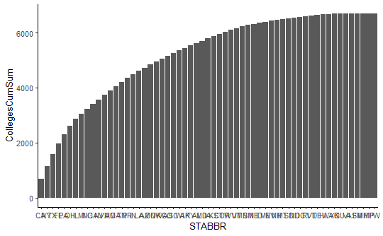

```r
base = ggplot(data=colleges_by_state,
              aes(x=STABBR, CollegesCumSum)) + theme_classic() + scale_x_discrete(limits = colleges_by_state$STABBR)
bar1 = base + geom_bar(stat = "identity")
bar1
```

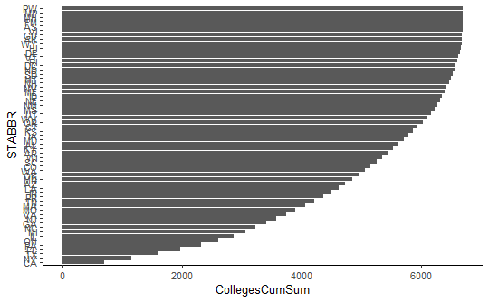

```r
#flip it
bar2 = base + geom_bar(stat = "identity") + coord_flip()
bar2
```

```r
bar3 = base + geom_bar(stat = "identity",color='grey90',
                      aes(fill=PercentCum<0.51),
                      show.legend = F) + coord_flip()
bar3
```

[output not shown]

###Change the colors on the graph showing where 50% of colleges/universities are

```r
bar4 = bar3 + scale_fill_manual(values=c("grey60", "#E67E22")) + scale_color_manual(values=c('black', 'black'))
bar4
```

[output not shown]

### Adding title and source

```r
titleText='A Majority of all U.S. Higher Education Institutions are in Ten States'
sourceText='Source: US Department of Education'
bar5 = bar4 + labs(title=titleText,
                   x='State or Territory Abbreviation',
                   y= 'Cumulative Number of Colleges and Universities',
                   caption = sourceText)
bar5
```

[output not shown]

```r
#load scales
library(scales)
```

###Reposition Title and Source Text, customize axis

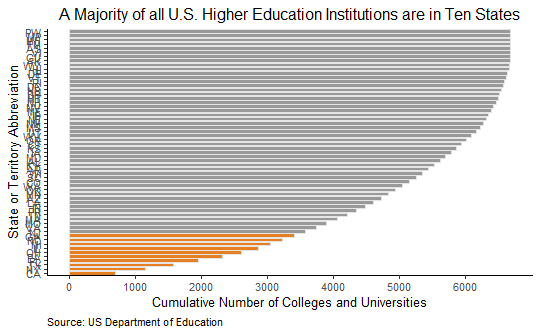

```r
bar6 = bar5 + theme(plot.caption = element_text(hjust = 0),
                    plot.title = element_text(hjust = 0.5)) + scale_y_continuous(breaks=c(0,1000, 2000, 3000, 4000, 5000, 6000),
                                   limits = c(0,6700)
                                    )
bar6
```

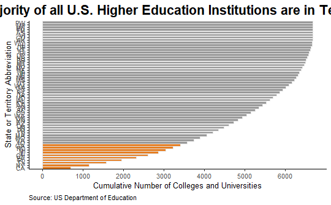

```r
bar7 = bar6 + theme(
    plot.title = element_text(face = 'bold', size = 18)
  )
bar7
```

###Add bold face to the names of the states that constitute 50% of higher education institutions

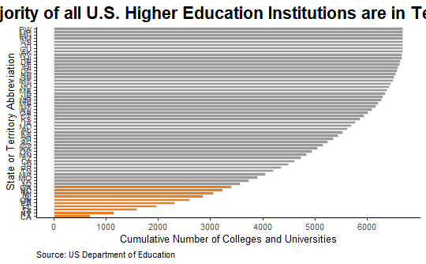

```r
states_51=colleges_by_state[colleges_by_state$PercentCum<0.51,"STABBR"]
bar8=bar7 + theme(axis.text.y = element_text(face=ifelse(colleges_by_state$STABBR%in%states_51,"bold","plain"),size=8))
bar8
```

###Generate Labels ONLY for the bars that create a majority of colleges/universities

```r
bar_labels <- colleges_by_state %>%
  mutate(bar_labels= ifelse(PercentCum<0.51, PercentCum, NA)) %>%
  select(bar_labels)
bar_labels2 <- as.vector(bar_labels$bar_labels)
bar_labels3 <- round(bar_labels2*100, digits = 1)
bar_labels4 <- paste0(bar_labels3, "%")
bar_labels5 <- replace(bar_labels4, c(11:59), NA)
```

###label the bars that create a majority of colleges/universities

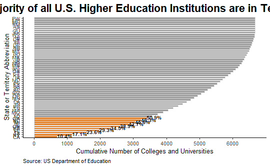

```r
bar9 = bar8 + geom_text(hjust= 0,
                        vjust = 0.3,
                        size = 3,
                        fontface = "bold",
                        aes(label = bar_labels5))
bar9
```

```r
#load ggthemes
library(ggthemes)
```

###Make the X and Y Axis Labels Bigger

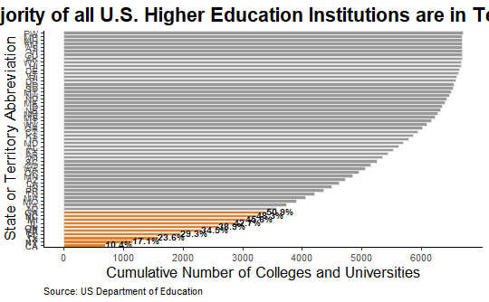

```r
bar10 = bar9 + theme(
  axis.title = element_text(size=14)
  , axis.title.y = element_text(vjust = 2)
)
bar10
```

#This Graph needs to be quite large in order to work. I make sure to export the graph with sufficient size.

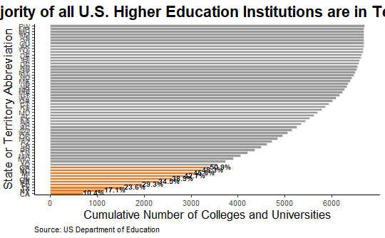

```r
#export image
bar10
ggsave('Conkling_Univariate_Numerical_Graph_PUBPOL543.jpg', device = 'jpeg', width = 11, height = 8.5, dpi = 300)
```